# Predicting the variation of song’s popularity through different variables from 2000-2020

Yash Baliyan

2022-08-17

# Introduction

## About Data

This data set contains of all the songs from 2000-2020, there are certain song attributes which will help me predict the popularity of songs. The song attributes like valence, danceabiolity, key can help judge the popularity and trends with the help of the GG plots.

## Summary

```
##   song_name         song_popularity  song_duration_ms   acousticness
##  Length:18835       Min.   :  0.00   Min.   :  12000   Min.   :0.000001
##  Class :character   1st Qu.: 40.00   1st Qu.: 184340   1st Qu.:0.024100
##  Mode  :character   Median : 56.00   Median : 211306   Median :0.132000
##                     Mean   : 52.99   Mean   : 218212   Mean   :0.258539
##                     3rd Qu.: 69.00   3rd Qu.: 242844   3rd Qu.:0.424000
##                     Max.   :100.00   Max.   :1799346   Max.   :0.996000
##   danceability        energy        instrumentalness         key
##  Min.   :0.0000   Min.   :0.00107   Min.   :0.0000000   Min.   : 0.000
##  1st Qu.:0.5330   1st Qu.:0.51000   1st Qu.:0.0000000   1st Qu.: 2.000
##  Median :0.6450   Median :0.67400   Median :0.0000114   Median : 5.000
##  Mean   :0.6333   Mean   :0.64499   Mean   :0.0780080   Mean   : 5.289
##  3rd Qu.:0.7480   3rd Qu.:0.81500   3rd Qu.:0.0025700   3rd Qu.: 8.000
##  Max.   :0.9870   Max.   :0.99900   Max.   :0.9970000   Max.   :11.000
##     liveness         loudness         audio_mode      speechiness
##  Min.   :0.0109   Min.   :-38.768   Min.   :0.0000   Min.   :0.0000
##  1st Qu.:0.0929   1st Qu.: -9.044   1st Qu.:0.0000   1st Qu.:0.0378
##  Median :0.1220   Median : -6.555   Median :1.0000   Median :0.0555
##  Mean   :0.1797   Mean   : -7.447   Mean   :0.6281   Mean   :0.1021
##  3rd Qu.:0.2210   3rd Qu.: -4.908   3rd Qu.:1.0000   3rd Qu.:0.1190
##  Max.   :0.9860   Max.   :  1.585   Max.   :1.0000   Max.   :0.9410
##      tempo        time_signature  audio_valence
##  Min.   :  0.00   Min.   :0.000   Min.   :0.000
##  1st Qu.: 98.37   1st Qu.:4.000   1st Qu.:0.335
##  Median :120.01   Median :4.000   Median :0.527
##  Mean   :121.07   Mean   :3.959   Mean   :0.528
##  3rd Qu.:139.93   3rd Qu.:4.000   3rd Qu.:0.725
##  Max.   :242.32   Max.   :5.000   Max.   :0.984
```

```
## 'data.frame':    18835 obs. of  15 variables:
##  $ song_name       : chr  "Boulevard of Broken Dreams" "In The End" "Seven Nation Army" "By The Way" ...
##  $ song_popularity : int  73 66 76 74 56 80 81 76 80 81 ...
##  $ song_duration_ms: int  262333 216933 231733 216933 223826 235893 199893 213800 222586 203346 ...
##  $ acousticness    : num  0.00552 0.0103 0.00817 0.0264 0.000954 0.00895 0.000504 0.00148 0.00108 0.00172 ...
##  $ danceability    : num  0.496 0.542 0.737 0.451 0.447 0.316 0.581 0.613 0.33 0.542 ...
##  $ energy          : num  0.682 0.853 0.463 0.97 0.766 0.945 0.887 0.953 0.936 0.905 ...
##  $ instrumentalness: num  2.94e-05 0.00 4.47e-01 3.55e-03 0.00 1.85e-06 1.11e-03 5.82e-04 0.00 1.04e-02 ...
##  $ key             : int  8 3 0 0 10 4 4 2 1 9 ...
##  $ liveness        : num  0.0589 0.108 0.255 0.102 0.113 0.396 0.268 0.152 0.0926 0.136 ...
##  $ loudness        : num  -4.09 -6.41 -7.83 -4.94 -5.07 ...
##  $ audio_mode      : int  1 0 1 1 1 0 0 1 1 1 ...
##  $ speechiness     : num  0.0294 0.0498 0.0792 0.107 0.0313 0.124 0.0624 0.0855 0.0917 0.054 ...
##  $ tempo           : num  167 105 124 122 172 ...
##  $ time_signature  : int  4 4 4 4 4 4 4 4 4 4 ...
##  $ audio_valence   : num  0.474 0.37 0.324 0.198 0.574 0.32 0.724 0.537 0.234 0.374 ...
```

## Story

My study helps people figure out what are the primary components to figure out the high song popularity of the songs, which has 15 columns and about 18000 rows of a range of songs with diverse song features. I took six song properties into account: audio valence, audio duration, key, danceability, liveness, and energy, all of which are non-binary in nature. Each of these variables contributes to the creation of a ggplot with song popularity to demonstrate the relationship between them. The histogram is the sole figure that takes into account only one variable, x; all other charts take into account two or three variables. The story’s main goal is to demonstrate a link between the statistics and the tables.

# Figure interpretation of data

## Histogram

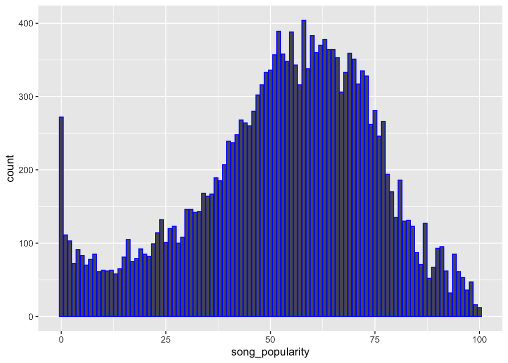

```r
ggplot(data = songs,aes(x=song_popularity))+geom_bar(colour="blue")
```

## Scatterplot

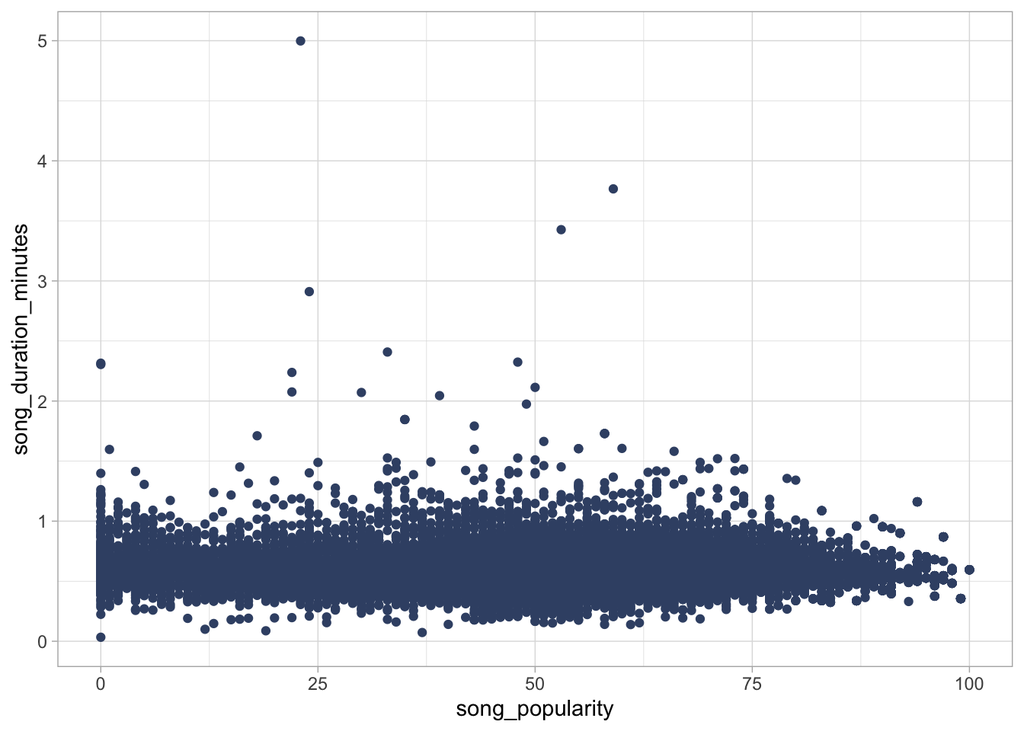

```r
sone <- songs%>%
  mutate(song_duration_minutes = (song_duration_ms/100)/60/60)

ggplot(sone) +
  aes(x = song_popularity, y = song_duration_minutes) +
  geom_point(shape = "circle", size = 1.5, colour = "#3C5074") +
  theme_light()
```

## Line graph and scatterplot for energy and song_popularity

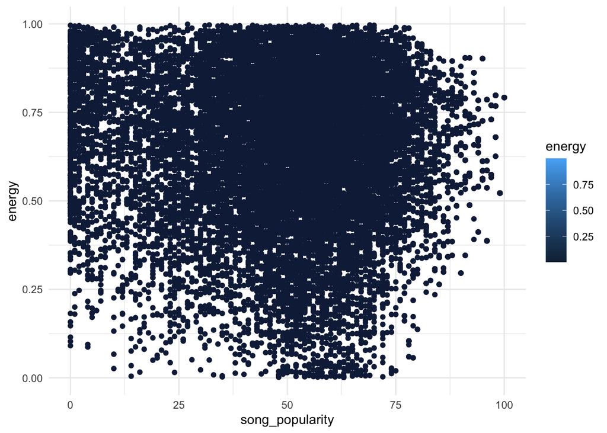

```r
 ggplot(songs) +
  aes(x = song_popularity, y = energy, fill = energy) +
  geom_point(shape = "circle", size = 1.5, colour = "#112446") +
  scale_fill_gradient() +
  theme_minimal()
```

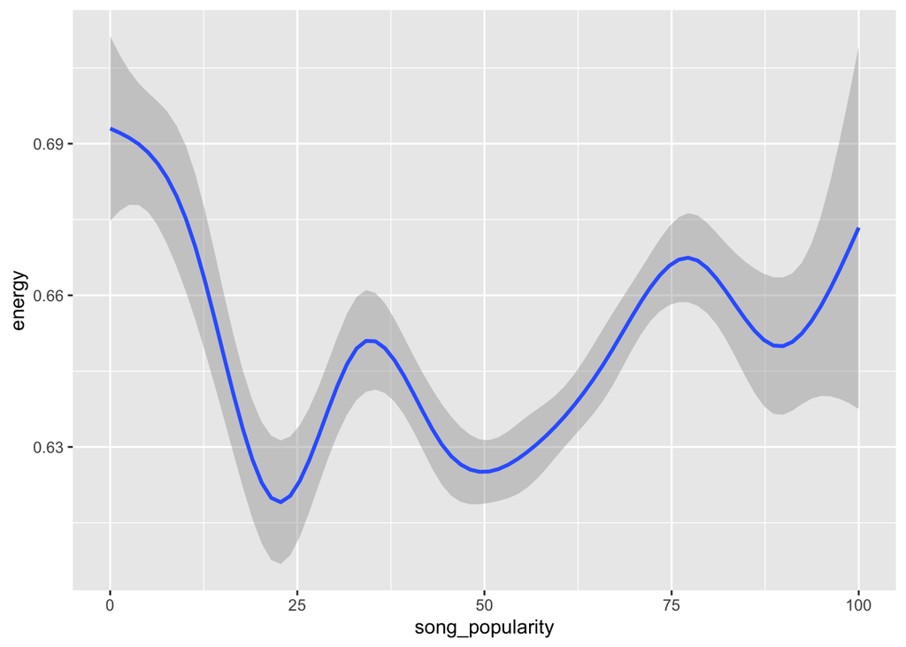

```r
ggplot(data = songs,aes(x=song_popularity, y=energy))+geom_smooth()
```

## Line graph for audio_valence and song_popularity.

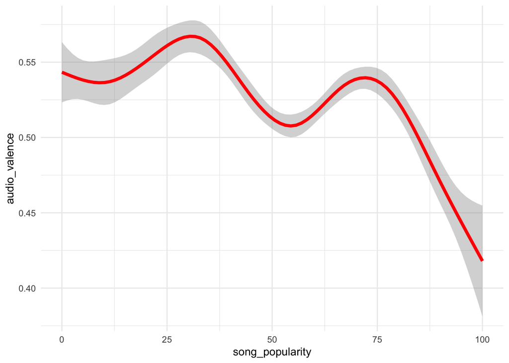

```r
ggplot(songs)+
  aes(x=song_popularity,y= audio_valence, fill=audio_valence)+
  geom_smooth(shape="circle", size=1.5, colour =" red")+
  scale_fill_gradient()+
  theme_minimal()
```

It is clear here that lesser the audio valence, the more would be the popularity of your the, eventually.

## Box plot analysis for audio_mode, key and danceability

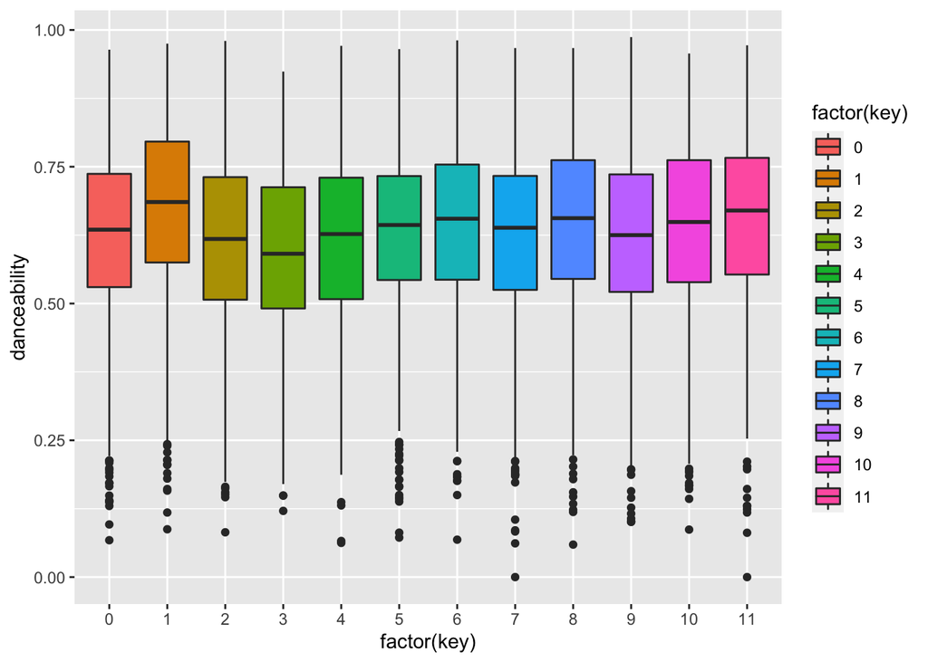

```r
ggplot(data = songs,aes(x=factor(key),y=danceability,fill = factor(key)))+
  geom_boxplot()
```

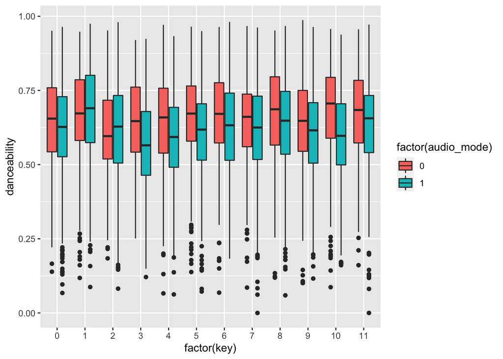

```r
ggplot(data = songs,aes(x=factor(key),y=danceability,fill = factor(audio_mode)))+
         geom_boxplot()
```

## line graph to show the relationship b/w song_popularity and key.

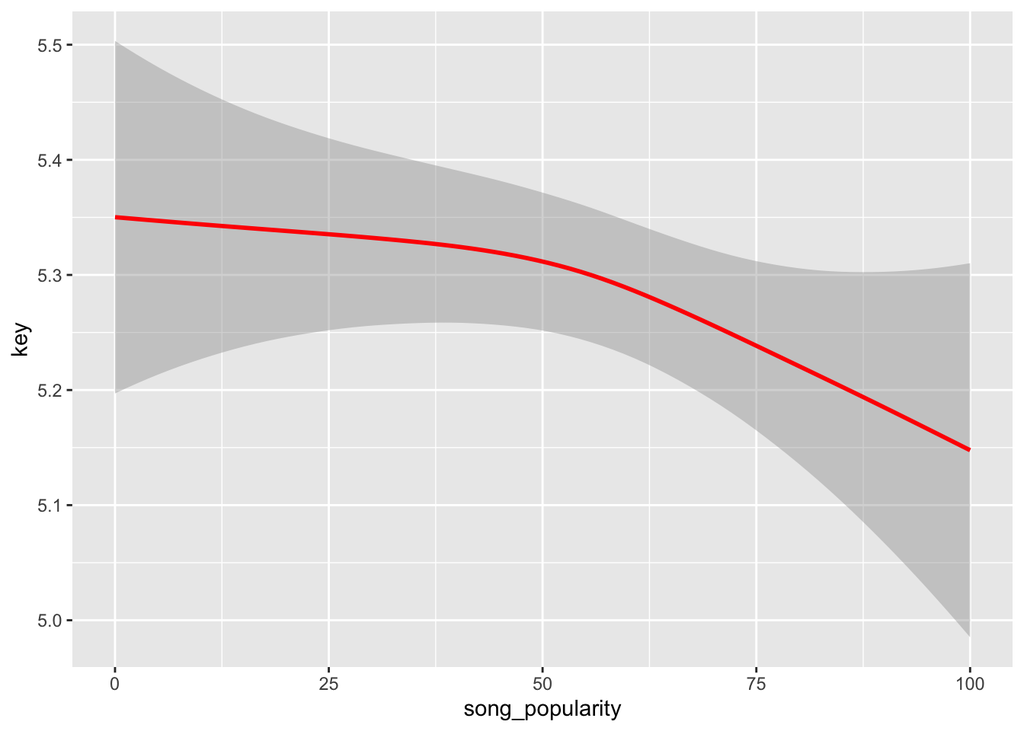

```r
ggplot(data = songs,aes(x=song_popularity, y=key))+geom_smooth( color = "red")
```

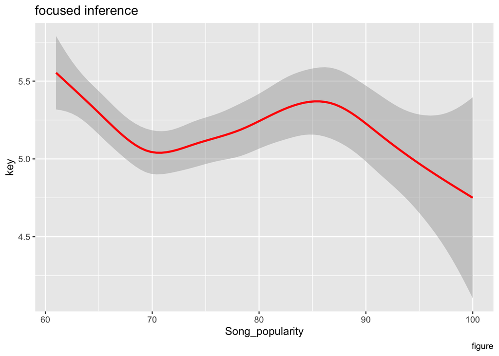

```r
Focus <- songs%>%
  filter(song_popularity>60)
ggplot(data= Focus,aes(x=song_popularity,y=key,stat_identity(na.rm=F)))+
geom_smooth(color="red")+labs(title = "focused inference",
                   caption = "figure", x = "Song_popularity", y = "key")
```

The figure here shows the indirect relationship of key and song_popularity,i.e song_popularity depends on less keys used for a song.

## Line graph analysis for song_popularity,liveness and danceability

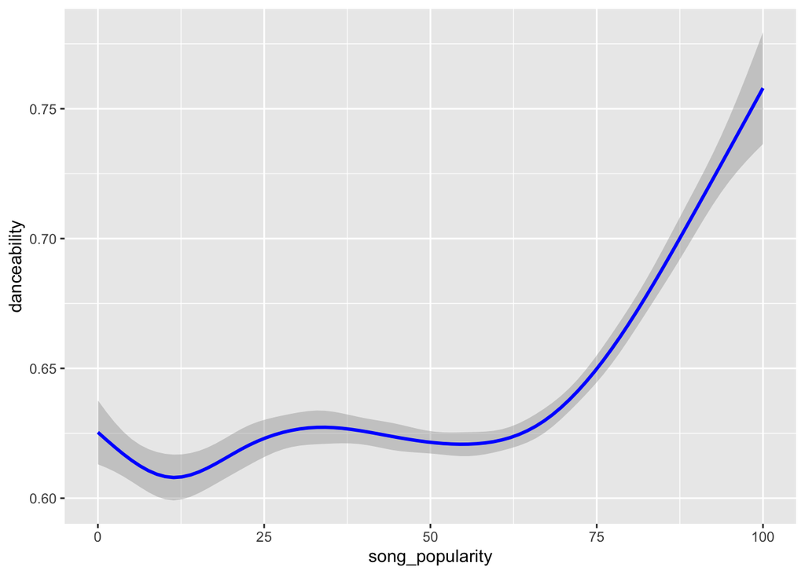

```r
ggplot(data = songs,aes(x=song_popularity, y=danceability))+geom_smooth( color = "blue")
```

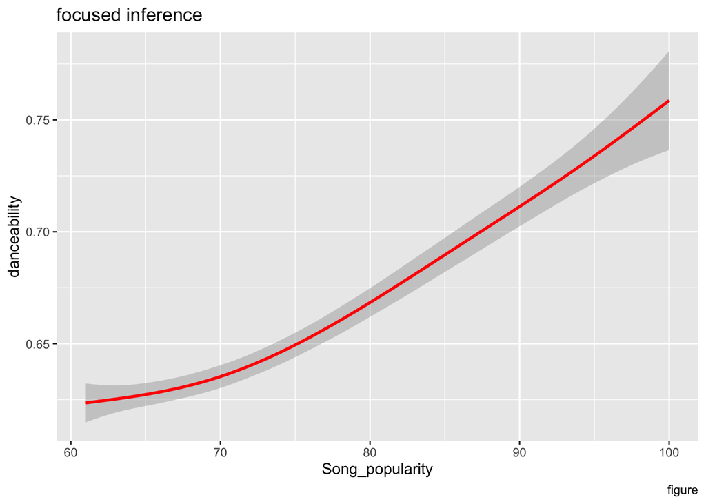

```r
dance <- songs%>%
filter(song_popularity>60)
ggplot(data= dance,aes(x=song_popularity,y=danceability,stat_identity(na.rm=F)))+
geom_smooth(color="red")+labs(title = "focused inference",
                   caption = "figure", x = "Song_popularity", y = "danceability")
```

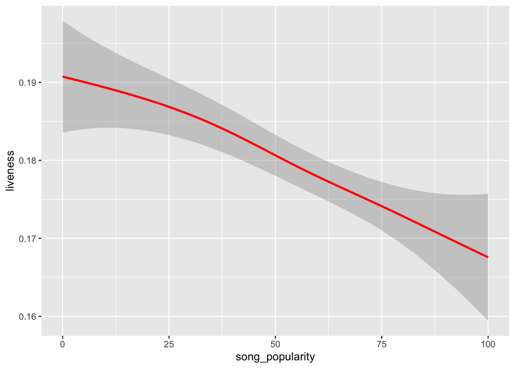

```r
ggplot(data = songs,aes(x=song_popularity, y=liveness))+geom_smooth(color = "red")
```

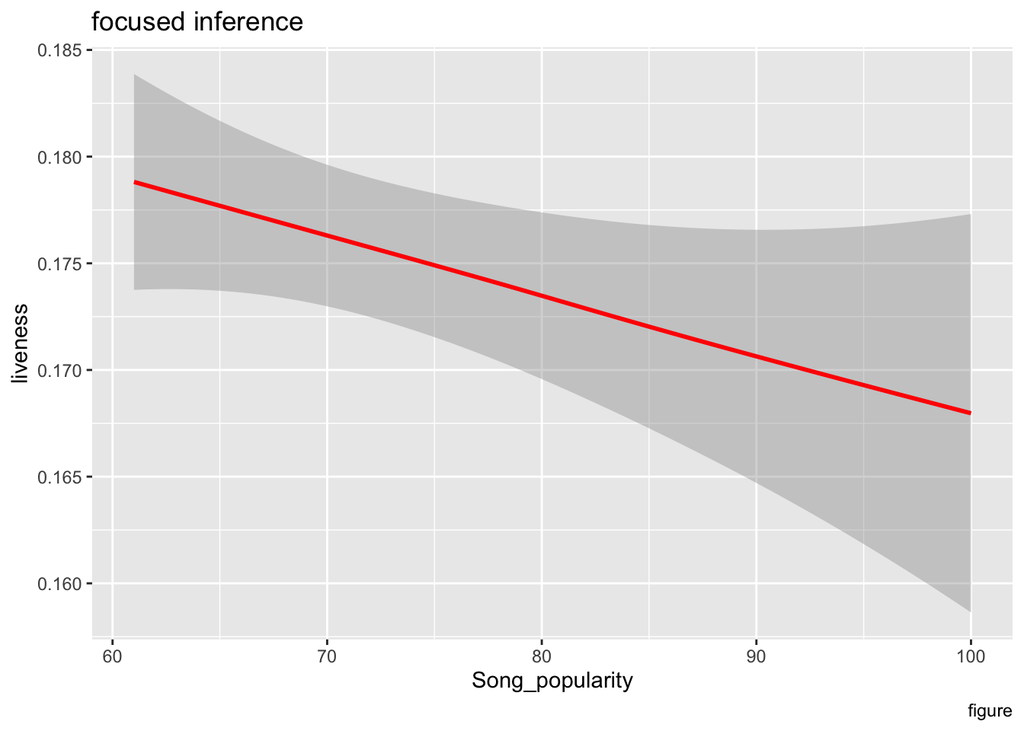

```r
live <- songs%>%
filter(song_popularity>60)
ggplot(data= live,aes(x=song_popularity,y=liveness,stat_identity(na.rm=F)))+
geom_smooth(color="red")+labs(title = "focused inference",
                   caption = "figure", x = "Song_popularity", y = "liveness")
```

Increasing the dancebility does have an effect on song popularity. keeping it lower would restrict the song from pushing it above 60 rating. Once a song increases it, so does its danceability

Liveliness and song_popularity has an indirect relation as you increase the livliness the popularity of the song decreases.

## Inference drawn for danceability through scatterplot and line graph both

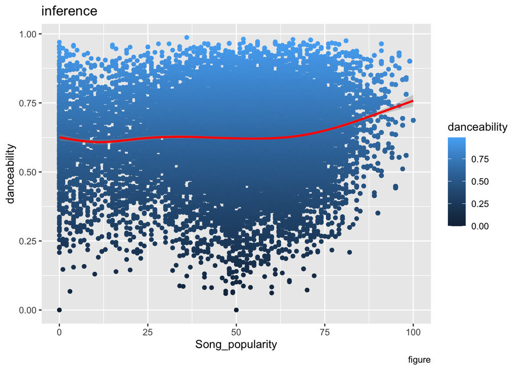

```r
ggplot(data= songs,aes(x=song_popularity,y=danceability,stat_identity(na.rm=F)))+geom_point(aes(color=danceability))+
geom_smooth(color="red")+labs(title = "inference",
                   caption = "figure", x = "Song_popularity", y = "danceability")
```

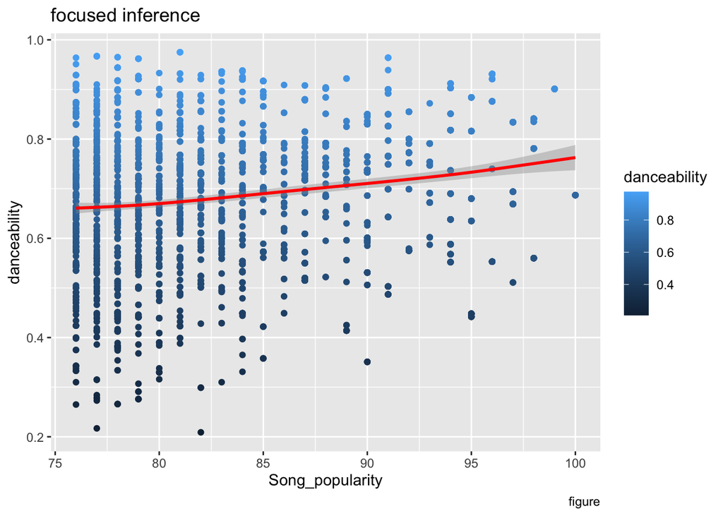

```r
zoom <- songs%>%
  filter(song_popularity>75)
ggplot(data= zoom,aes(x=song_popularity,y=danceability,stat_identity(na.rm=F)))+geom_point(aes(color=danceability))+
geom_smooth(color="red")+labs(title = "focused inference",
                   caption = "figure", x = "Song_popularity", y = "danceability")
```

The following figure shows that popularity is constant till song_popularity is 75 i.e. from this number ownwards the ratings increases as the danceability increases.

# Table

## Repetition of top songs. (above 95).

```r
sume <- songs%>%
  group_by(song_name)%>%
  filter(song_popularity>95)%>%
  summarise(song_na=n())%>%
  kbl(caption="repeated top songs",align="cc")
sume%>% kable_styling(bootstrap_options = c("striped","bordered"))%>%
  kable_material(html_font="times new roman",font_size=12) %>%
  kable_paper(full_width=F)
```

repeated top songs

| song_name | song_na |
| --- | --- |
| Be Alright | 14 |
| Eastside (with Halsey & Khalid) | 10 |
| Falling Down | 12 |
| FEFE (feat. Nicki Minaj & Murda Beatz) | 19 |
| Happier | 12 |
| I Love It (& Lil Pump) | 16 |
| In My Feelings | 3 |
| In My Mind | 9 |
| Lucid Dreams | 2 |
| Lucky You (feat. Joyner Lucas) | 12 |
| Moonlight | 4 |
| Promises (with Sam Smith) | 16 |
| SAD! | 4 |
| SICKO MODE | 13 |
| Taki Taki (with Selena Gomez, Ozuna & Cardi B) | 18 |

```r
Top_Songs <- songs%>%
  filter(song_popularity>95)%>%
  select(song_name,song_popularity,danceability,key,liveness,energy,audio_valence)%>%
  arrange(desc(song_popularity),10)%>%
  kbl(caption="Top songs",align="cc")
Top_Songs%>% kable_styling(bootstrap_options = c("striped","bordered"))%>%
  kable_material(html_font="times new roman",font_size=12) %>%
  kable_paper(full_width=F)
```

Top songs

| song_name | song_popularity | danceability | key | liveness | energy | audio_valence |
| --- | --- | --- | --- | --- | --- | --- |
| Happier | 100 | 0.687 | 5 | 0.1670 | 0.792 | 0.671 |
| Happier | 100 | 0.687 | 5 | 0.1670 | 0.792 | 0.671 |
| Happier | 100 | 0.687 | 5 | 0.1670 | 0.792 | 0.671 |
| Happier | 100 | 0.687 | 5 | 0.1670 | 0.792 | 0.671 |
| Happier | 100 | 0.687 | 5 | 0.1670 | 0.792 | 0.671 |
| Happier | 100 | 0.687 | 5 | 0.1670 | 0.792 | 0.671 |
| Happier | 100 | 0.687 | 5 | 0.1670 | 0.792 | 0.671 |
| Happier | 100 | 0.687 | 5 | 0.1670 | 0.792 | 0.671 |
| Happier | 100 | 0.687 | 5 | 0.1670 | 0.792 | 0.671 |
| Happier | 100 | 0.687 | 5 | 0.1670 | 0.792 | 0.671 |
| Happier | 100 | 0.687 | 5 | 0.1670 | 0.792 | 0.671 |
| Happier | 100 | 0.687 | 5 | 0.1670 | 0.792 | 0.671 |
| I Love It (& Lil Pump) | 99 | 0.901 | 2 | 0.2590 | 0.522 | 0.329 |
| I Love It (& Lil Pump) | 99 | 0.901 | 2 | 0.2590 | 0.522 | 0.329 |
| I Love It (& Lil Pump) | 99 | 0.901 | 2 | 0.2590 | 0.522 | 0.329 |
| I Love It (& Lil Pump) | 99 | 0.901 | 2 | 0.2590 | 0.522 | 0.329 |
| I Love It (& Lil Pump) | 99 | 0.901 | 2 | 0.2590 | 0.522 | 0.329 |
| I Love It (& Lil Pump) | 99 | 0.901 | 2 | 0.2590 | 0.522 | 0.329 |
| I Love It (& Lil Pump) | 99 | 0.901 | 2 | 0.2590 | 0.522 | 0.329 |
| I Love It (& Lil Pump) | 99 | 0.901 | 2 | 0.2590 | 0.522 | 0.329 |
| I Love It (& Lil Pump) | 99 | 0.901 | 2 | 0.2590 | 0.522 | 0.329 |
| I Love It (& Lil Pump) | 99 | 0.901 | 2 | 0.2590 | 0.522 | 0.329 |
| I Love It (& Lil Pump) | 99 | 0.901 | 2 | 0.2590 | 0.522 | 0.329 |
| I Love It (& Lil Pump) | 99 | 0.901 | 2 | 0.2590 | 0.522 | 0.329 |
| I Love It (& Lil Pump) | 99 | 0.901 | 2 | 0.2590 | 0.522 | 0.329 |
| I Love It (& Lil Pump) | 99 | 0.901 | 2 | 0.2590 | 0.522 | 0.329 |
| I Love It (& Lil Pump) | 99 | 0.901 | 2 | 0.2590 | 0.522 | 0.329 |
| I Love It (& Lil Pump) | 99 | 0.901 | 2 | 0.2590 | 0.522 | 0.329 |
| Taki Taki (with Selena Gomez, Ozuna & Cardi B) | 98 | 0.841 | 1 | 0.0618 | 0.798 | 0.591 |
| Taki Taki (with Selena Gomez, Ozuna & Cardi B) | 98 | 0.841 | 1 | 0.0618 | 0.798 | 0.591 |

[output cut: 134 more lines]

## Popularity with Danceability

```r
son <- songs%>%
  select(song_name,song_popularity,danceability,liveness,audio_valence,speechiness,tempo,key,energy)%>%
  mutate(popular_dance=round((song_popularity*danceability),2))%>%
  filter(popular_dance>=80,song_popularity>95)%>%
   kbl(caption="popular_dance",align="cc")
son%>% kable_styling(bootstrap_options = c("striped","bordered"))%>%
  kable_material(html_font="times new roman",font_size=12) %>%
  kable_paper(full_width=F)
```

popular_dance

| song_name | song_popularity | danceability | liveness | audio_valence | speechiness | tempo | key | energy | popular_dance |
| --- | --- | --- | --- | --- | --- | --- | --- | --- | --- |
| Taki Taki (with Selena Gomez, Ozuna & Cardi B) | 98 | 0.841 | 0.0618 | 0.591 | 0.2290 | 95.948 | 1 | 0.798 | 82.42 |
| I Love It (& Lil Pump) | 99 | 0.901 | 0.2590 | 0.329 | 0.3300 | 104.053 | 2 | 0.522 | 89.20 |
| SICKO MODE | 97 | 0.834 | 0.1240 | 0.446 | 0.2220 | 155.008 | 8 | 0.730 | 80.90 |
| Lucky You (feat. Joyner Lucas) | 96 | 0.876 | 0.1270 | 0.575 | 0.3060 | 153.068 | 10 | 0.786 | 84.10 |
| FEFE (feat. Nicki Minaj & Murda Beatz) | 96 | 0.931 | 0.1360 | 0.376 | 0.4120 | 125.978 | 1 | 0.387 | 89.38 |
| Lucky You (feat. Joyner Lucas) | 96 | 0.876 | 0.1270 | 0.575 | 0.3060 | 153.068 | 10 | 0.786 | 84.10 |
| FEFE (feat. Nicki Minaj & Murda Beatz) | 96 | 0.931 | 0.1360 | 0.376 | 0.4120 | 125.978 | 1 | 0.387 | 89.38 |
| Taki Taki (with Selena Gomez, Ozuna & Cardi B) | 98 | 0.841 | 0.0618 | 0.591 | 0.2290 | 95.948 | 1 | 0.798 | 82.42 |
| Lucky You (feat. Joyner Lucas) | 96 | 0.876 | 0.1270 | 0.575 | 0.3060 | 153.068 | 10 | 0.786 | 84.10 |
| I Love It (& Lil Pump) | 99 | 0.901 | 0.2590 | 0.329 | 0.3300 | 104.053 | 2 | 0.522 | 89.20 |
| SICKO MODE | 97 | 0.834 | 0.1240 | 0.446 | 0.2220 | 155.008 | 8 | 0.730 | 80.90 |
| Taki Taki (with Selena Gomez, Ozuna & Cardi B) | 98 | 0.841 | 0.0618 | 0.591 | 0.2290 | 95.948 | 1 | 0.798 | 82.42 |
| I Love It (& Lil Pump) | 99 | 0.901 | 0.2590 | 0.329 | 0.3300 | 104.053 | 2 | 0.522 | 89.20 |
| Lucky You (feat. Joyner Lucas) | 96 | 0.876 | 0.1270 | 0.575 | 0.3060 | 153.068 | 10 | 0.786 | 84.10 |
| FEFE (feat. Nicki Minaj & Murda Beatz) | 96 | 0.931 | 0.1360 | 0.376 | 0.4120 | 125.978 | 1 | 0.387 | 89.38 |
| Taki Taki (with Selena Gomez, Ozuna & Cardi B) | 98 | 0.841 | 0.0618 | 0.591 | 0.2290 | 95.948 | 1 | 0.798 | 82.42 |
| I Love It (& Lil Pump) | 99 | 0.901 | 0.2590 | 0.329 | 0.3300 | 104.053 | 2 | 0.522 | 89.20 |
| FEFE (feat. Nicki Minaj & Murda Beatz) | 96 | 0.931 | 0.1360 | 0.376 | 0.4120 | 125.978 | 1 | 0.387 | 89.38 |
| Lucky You (feat. Joyner Lucas) | 96 | 0.876 | 0.1270 | 0.575 | 0.3060 | 153.068 | 10 | 0.786 | 84.10 |
| FEFE (feat. Nicki Minaj & Murda Beatz) | 96 | 0.931 | 0.1360 | 0.376 | 0.4120 | 125.978 | 1 | 0.387 | 89.38 |
| SICKO MODE | 97 | 0.834 | 0.1240 | 0.446 | 0.2220 | 155.008 | 8 | 0.730 | 80.90 |
| Taki Taki (with Selena Gomez, Ozuna & Cardi B) | 98 | 0.841 | 0.0618 | 0.591 | 0.2290 | 95.948 | 1 | 0.798 | 82.42 |
| SICKO MODE | 97 | 0.834 | 0.1240 | 0.446 | 0.2220 | 155.008 | 8 | 0.730 | 80.90 |
| FEFE (feat. Nicki Minaj & Murda Beatz) | 96 | 0.931 | 0.1360 | 0.376 | 0.4120 | 125.978 | 1 | 0.387 | 89.38 |
| I Love It (& Lil Pump) | 99 | 0.901 | 0.2590 | 0.329 | 0.3300 | 104.053 | 2 | 0.522 | 89.20 |
| Taki Taki (with Selena Gomez, Ozuna & Cardi B) | 98 | 0.841 | 0.0618 | 0.591 | 0.2290 | 95.948 | 1 | 0.798 | 82.42 |
| I Love It (& Lil Pump) | 99 | 0.901 | 0.2590 | 0.329 | 0.3300 | 104.053 | 2 | 0.522 | 89.20 |
| SICKO MODE | 97 | 0.834 | 0.1240 | 0.446 | 0.2220 | 155.008 | 8 | 0.730 | 80.90 |
| In My Feelings | 98 | 0.835 | 0.3960 | 0.350 | 0.1250 | 91.030 | 1 | 0.626 | 81.83 |
| Moonlight | 96 | 0.921 | 0.1020 | 0.711 | 0.0804 | 128.009 | 9 | 0.537 | 88.42 |

[output cut: 55 more lines]

# Figure interpretation of data through Regression

```r
Regression <- lm(song_popularity~danceability+liveness+audio_valence+energy, data = songs)
summary(Regression)
```

```
##
## Call:
## lm(formula = song_popularity ~ danceability + liveness + audio_valence +
##     energy, data = songs)
##
## Residuals:
##     Min      1Q  Median      3Q     Max
## -61.590 -12.528   2.691  16.015  46.795
##
## Coefficients:
##               Estimate Std. Error t value Pr(>|t|)
## (Intercept)    44.6298     0.8161  54.689  < 2e-16 ***
## danceability   19.0122     1.0753  17.681  < 2e-16 ***
## liveness       -4.7071     1.1182  -4.210 2.57e-05 ***
## audio_valence  -9.7330     0.7226 -13.470  < 2e-16 ***
## energy          3.5737     0.7905   4.521 6.20e-06 ***
## ---
## Signif. codes:  0 '***' 0.001 '**' 0.01 '*' 0.05 '.' 0.1 ' ' 1
##
## Residual standard error: 21.67 on 18830 degrees of freedom
## Multiple R-squared:  0.02119,    Adjusted R-squared:  0.02098
## F-statistic: 101.9 on 4 and 18830 DF,  p-value: < 2.2e-16
```